# Linear Regression

## Where we left off

- **Day 9:** statistical learning = estimating \(f\) in \(Y = f(X) + \varepsilon\)
  - for **prediction** or for **inference**
  - judge predictions by **test** MSE; too much flexibility overfits
- We placed methods on a scale from flexible to interpretable.
- **Today: the interpretable end — linear regression.**
  - Our first method for actually estimating \(f\)
  - Its coefficients answer inference questions directly
  - It is also the baseline every fancier method has to beat

## 1. Fitting a line

## The model

**Simple linear regression** assumes \(f\) is a straight line:

\[Y = \beta_0 + \beta_1 X + \varepsilon\]

| Piece | Name | In the Auto example |
| --- | --- | --- |
| *β*<sub>0</sub> | **intercept**: predicted *Y* when *X* = 0 | mpg of a 0-hp car |
| *β*<sub>1</sub> | **slope**: change in *Y* when *X* rises by 1 | mpg lost per extra horsepower |
| *ε* | error, as on Day 9 | everything else about the car |

- \(\beta_0\) and \(\beta_1\) are the **coefficients**. They are unknown.
- We estimate them from data and write the estimates with hats: \(\hat\beta_0, \hat\beta_1\).

## Which line?

> **Many lines pass through this cloud. Which one is “best”?**

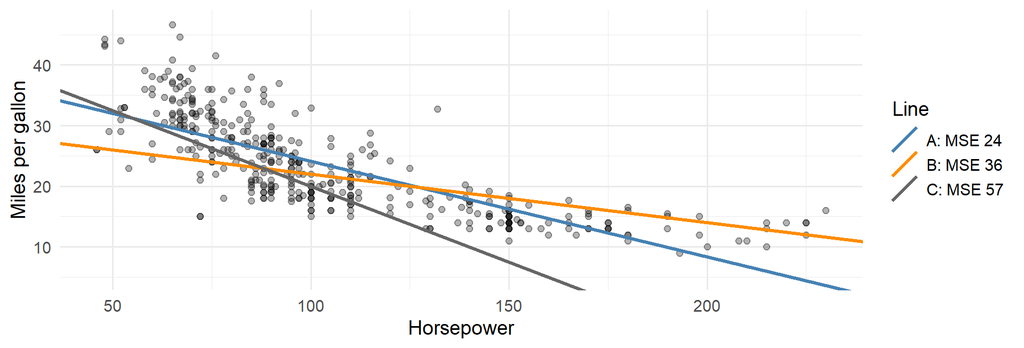

Score each line with Day 9’s **MSE**, and pick the lowest.

## Residuals: the misses get a name

For each car \(i\), a line gives a **fitted value** \(\hat y_i = \hat\beta_0 + \hat\beta_1 x_i\).

The **residual** \(e_i = y_i - \hat y_i\) is what Day 9 called the “miss.”

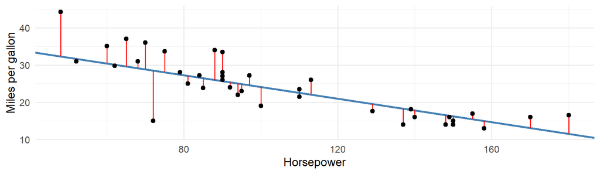

## Least squares

**Least squares** picks the \(\hat\beta_0, \hat\beta_1\) with the lowest **training MSE**:

\[\text{MSE} = \frac{1}{n}\sum_{i=1}^n e_i^2 = \frac{1}{n}\sum_{i=1}^n \big(y_i - \hat\beta_0 - \hat\beta_1 x_i\big)^2\]

- ISL drops the \(\frac{1}{n}\) and calls the sum the **residual sum of squares**: RSS = *n* × MSE. The same line minimizes both.
- Calculus gives a formula, so no searching is needed:

\[\hat\beta_1 = \frac{\sum (x_i - \bar x)(y_i - \bar y)}{\sum (x_i - \bar x)^2}, \qquad \hat\beta_0 = \bar y - \hat\beta_1 \bar x\]

## Fitting the line in R

`lm()` (“linear model”) finds the least squares line for us.

```r
fit_hp <- lm(mpg ~ horsepower, data = Auto)
coef(fit_hp)
## (Intercept)  horsepower
##  39.9358610  -0.1578447
```

**Reading the coefficients**

- **Slope:** each extra horsepower is associated with 0.158 fewer mpg, or about 1.6 mpg per 10 hp.
- **Intercept:** a 0-hp car would get 39.9 mpg.
  - Extrapolated: the least powerful car in the data has 46 hp.
  - Still needed to pin down where the line sits.

## 2. How sure are we?

## A different sample, a different line

> **If we had collected a different set of cars, would we get the same slope?**

Treat the 392 cars as the population. Draw 30 samples of 40 cars and fit a line to each:

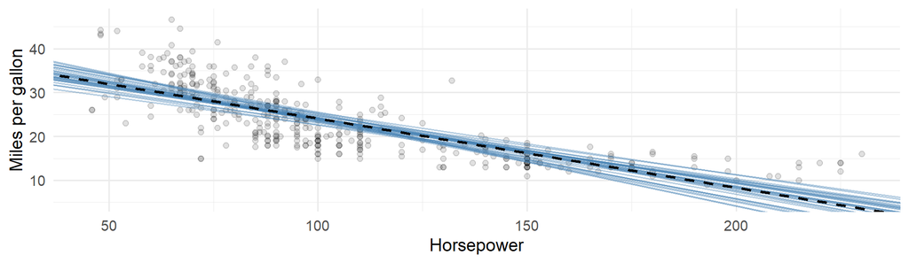

The lines disagree: Day 9’s **variance**, now for a coefficient.

## Standard errors and confidence intervals

In practice we get **one** sample, but we can still estimate that spread.

- **Standard error** \(\text{SE}(\hat\beta_1)\): how much \(\hat\beta_1\) would typically move from sample to sample.
  - Smaller with more data, more spread in \(X\), and less noise.
- **95% confidence interval:** about \(\hat\beta_1 \pm 2\cdot\text{SE}(\hat\beta_1)\).
  - Built this way, the interval captures the true \(\beta_1\) in 95% of samples.

```r
confint(fit_hp)
##                 2.5 %     97.5 %
## (Intercept) 38.525212 41.3465103
## horsepower  -0.170517 -0.1451725
```

The true mpg cost of one horsepower is plausibly between 0.145 and 0.171.

## Is there a relationship at all?

A **hypothesis test** asks whether the slope could really be zero.

- \(H_0\): \(\beta_1 = 0\), so \(X\) has no linear relationship with \(Y\).
- **t-statistic** \(= \hat\beta_1 / \text{SE}(\hat\beta_1)\): how many SEs the estimate sits from 0.
- **p-value:** if \(H_0\) were true, the probability of a \(|t|\) at least this large.
  - Small p-value (say < 0.05): reject \(H_0\); the relationship is unlikely to be chance.
- For horsepower: \(t =\) -24.5. The p-value is essentially 0.

**The 95% CI and the test agree:** the CI excludes 0 exactly when \(p < 0.05\).

## Reading `summary()`

```r
summary(fit_hp)
```

```
Coefficients:
             Estimate Std. Error t value Pr(>|t|)
(Intercept) 39.935861   0.717499   55.66   <2e-16 ***
horsepower  -0.157845   0.006446  -24.49   <2e-16 ***
---
Signif. codes:  0 '***' 0.001 '**' 0.01 '*' 0.05 '.' 0.1 ' ' 1

Residual standard error: 4.906 on 390 degrees of freedom
Multiple R-squared:  0.6059,    Adjusted R-squared:  0.6049
F-statistic: 599.7 on 1 and 390 DF,  p-value: < 2.2e-16
```

- **Estimate:** \(\hat\beta_0\) and \(\hat\beta_1\). **Std. Error:** their SEs.
- **t value** = Estimate / Std. Error. **Pr(>|t|):** the p-value. Stars flag small p-values.
- **Residual standard error** and **R-squared** describe the whole fit (next two slides).

## Fit measure 1: residual standard error

> **How far off is a typical prediction?**

**Residual standard error (RSE):** the typical distance between a car and the line, in the units of \(Y\).

- RSE = 4.9: a typical car’s mpg is about 5 mpg above or below the line.
- Is that big? Compare it to \(Y\) itself: the average car gets 23.4 mpg, so a typical miss is about 21% of that.
- Because it’s in the units of \(Y\), whether an RSE is “good” depends on the problem: 5 mpg is large; $5 on a house price is tiny.

## Fit measure 2: \(R^2\)

> **How much of the variation in mpg does horsepower explain?**

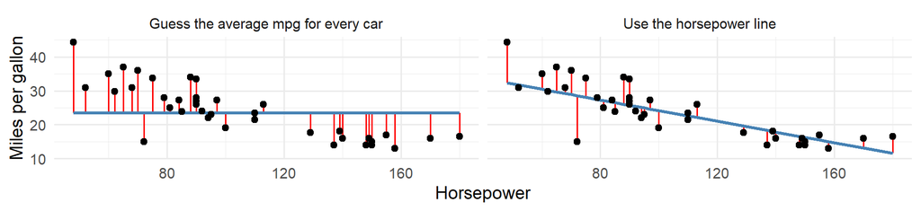

\(R^2\) = the share of the left panel’s squared misses that the line removes.

- \(R^2 =\) 0.61: horsepower explains 61% of the variation in mpg.
- 0 = no better than guessing the average; 1 = every car exactly on the line.
- No units, so unlike RSE it can be compared across different outcomes.

## 3. More than one predictor

## Is it the horsepower, or the weight?

> **Powerful cars tend to be heavy. Is horsepower costing mileage, or weight?**

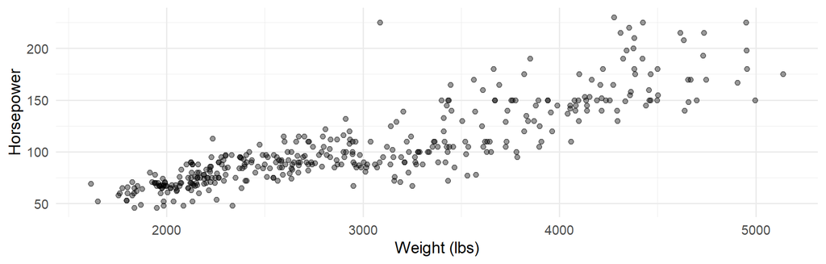

Correlation 0.86. The simple regression can’t tell their effects apart.

## Multiple linear regression

Give each predictor its own slope:

\[Y = \beta_0 + \beta_1 X_1 + \beta_2 X_2 + \dots + \beta_p X_p + \varepsilon\]

- \(\beta_j\) = change in \(Y\) when \(X_j\) rises by 1, **holding the other predictors fixed**.
- Still fit by least squares: choose all the \(\hat\beta\)’s to minimize RSS.
- In R, add predictors with `+`:

```r
fit_both <- lm(mpg ~ horsepower + weight, data = Auto)
coef(fit_both)
##  (Intercept)   horsepower       weight
## 45.640210840 -0.047302863 -0.005794157
```

## The horsepower slope shrinks

| Model | Horsepower slope | Its SE | R² |
| --- | --- | --- | --- |
| `mpg ~ horsepower` | -0.158 | 0.0064 | 0.61 |
| `mpg ~ horsepower + weight` | **-0.047** | 0.0111 | 0.71 |

- Alone, horsepower gets credit for weight’s effect too.
- Comparing cars of the **same weight**, an extra 10 hp costs only about 0.5 mpg, not 1.6.
- **Omitted variable bias:** leave out a predictor that is correlated with \(X\) and affects \(Y\), and \(X\)’s slope absorbs its effect.

## Predicting, with honest uncertainty

> **What mpg should we expect from a 98-hp car?** *(98 hp is about average.)*

```r
new_car <- data.frame(horsepower = 98)
predict(fit_hp, new_car, interval = "confidence")
##        fit      lwr      upr
## 1 24.46708 23.97308 24.96108
predict(fit_hp, new_car, interval = "prediction")
##        fit     lwr      upr
## 1 24.46708 14.8094 34.12476
```

- **Confidence interval:** the *average* mpg of all 98-hp cars. Reflects only uncertainty about the line.
- **Prediction interval:** *one* 98-hp car, which can land well off the line. A typical miss is RSE ≈ 4.9 mpg, so this interval is much wider.
- Same center for both. More data narrows the CI, but the PI never gets much narrower than ±2·RSE: Day 9’s **irreducible error**.

## 4. Checking the fit

## Is a straight line right?

> **Do the residuals show a pattern the line missed?**

A **residual plot** puts fitted values on the x-axis and residuals on the y-axis.

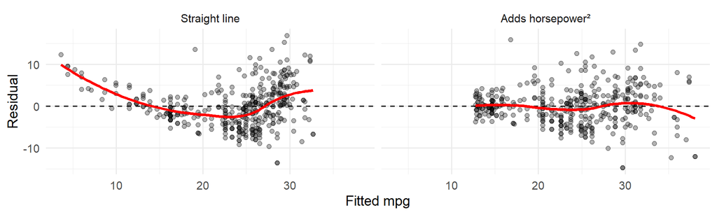

The U-shape says the truth bends. Adding horsepower² (Day 9’s degree 2) removes most of it. Still “linear” regression: linear in the \(\beta\)’s.

## Summary

**Linear regression:** \(Y = \beta_0 + \beta_1 X_1 + \dots + \beta_p X_p + \varepsilon\), fit by least squares (lowest training MSE).

- **Interpret** \(\hat\beta_j\): change in \(Y\) per unit of \(X_j\), holding the other predictors fixed.
- **Uncertainty:** SEs, CIs, and p-values ask whether a slope could be 0.
- **Fit:** RSE (typical miss, in units of \(Y\)) and \(R^2\) (share of variation explained).
- **Omitted variables** can bias a slope; adding the right one changes the story.
- **Check** the residual plot before trusting the line.

**Next time:** what if \(Y\) is a category, not a number? **Classification.**

## For rest of class

- Work on the `day10_activity`
  - you’ll estimate how price affects car-seat sales, then see the answer change once you hold competitors’ prices fixed
- Ask me questions if you run into issues